FJ

# Feidhelm Joyce

Business & Data Analyst  
Boston, MA

linkedin.com/in/feidhelmjoyce  
github.com/FeidhelmJ

MARKETING ANALYTICS

## Data Exploration & Manipulation

← Back to Marketing Analytics

```
import pandas as pd
import numpy as np
import matplotlib.pyplot as plt
import seaborn as sns
```

**Exploratory Data Analysis: Exploration & Manipulation**

A.

Call the head() function on this dataframe and look at your results.

```
lobster_25 = pd.read_csv('lobster_25.csv')
pd.set_option('display.max_columns', None)
lobster_25.head()
```

|  | Date | Day_of_Week | season_week_rel | Is_Holiday | Total_Visitors | Passholder_Percentage | Day_Tickets_Sold | Avg_Ticket_Price | Gate_Revenue | Revenue_Food | Revenue_Merch | Revenue_Arcade | Total_Revenue | Total_Labor_Hours | International_Visitors | High_Temperature | Precipitation | Weather_Type | Weather_Code | Promo_Flag | Promo_Type | Cruise_Docked | Is_Special_Event | Special_Events | Attraction_Tier | Zone_ID | Per_Capita_Spend |
| --- | --- | --- | --- | --- | --- | --- | --- | --- | --- | --- | --- | --- | --- | --- | --- | --- | --- | --- | --- | --- | --- | --- | --- | --- | --- | --- | --- |
| 0 | 2025-05-26 | Monday | 1 | 1 | 1769 | 48.65 | 908 | 77.42 | 70297.36 | 40521.91 | 15881.29 | 3195.46 | 129896.02 | 238.1 | 114.0 | 74.6 | 1 | Thunderstorms | 4 | 0 | NaN | 0 | 0 | NaN | 2 | 101 | 73.43 |
| 1 | 2025-05-27 | Tuesday | 1 | 0 | 1717 | 60.58 | 677 | 69.80 | 47254.60 | 35298.92 | NaN | 2977.63 | 101812.36 | 253.4 | 255.0 | 74.0 | 0 | Partly Cloudy | 2 | 0 | NaN | 0 | 0 | NaN | 2 | 101 | 59.30 |
| 2 | 2025-05-28 | Wednesday | 1 | 0 | 1600 | 30.84 | 1107 | 70.09 | 77589.63 | 36495.95 | 14954.04 | 2683.58 | 131723.20 | 213.3 | 160.0 | 76.8 | 0 | Partly Cloudy | 2 | 0 | NaN | 0 | 0 | NaN | 3 | 103 | 82.33 |
| 3 | 2025-05-29 | Thursday | 1 | 0 | 1037 | 19.02 | 840 | 72.30 | 60732.00 | 22486.65 | 9517.06 | 1831.98 | 94567.69 | 192.7 | 83.0 | 75.4 | 1 | Showers | 3 | 0 | NaN | 0 | 0 | NaN | 2 | 101 | 91.19 |
| 4 | 2025-05-30 | Friday | 1 | 0 | 1671 | 66.18 | 565 | 68.11 | 38482.15 | 40705.15 | 15727.62 | 3115.94 | 98030.86 | 235.9 | 158.0 | 80.7 | 0 | Partly Cloudy | 2 | 0 | NaN | 0 | 0 | NaN | 1 | 104 | 58.67 |

```
lobster_25.tail()
```

|  | Date | Day_of_Week | season_week_rel | Is_Holiday | Total_Visitors | Passholder_Percentage | Day_Tickets_Sold | Avg_Ticket_Price | Gate_Revenue | Revenue_Food | Revenue_Merch | Revenue_Arcade | Total_Revenue | Total_Labor_Hours | International_Visitors | High_Temperature | Precipitation | Weather_Type | Weather_Code | Promo_Flag | Promo_Type | Cruise_Docked | Is_Special_Event | Special_Events | Attraction_Tier | Zone_ID | Per_Capita_Spend |
| --- | --- | --- | --- | --- | --- | --- | --- | --- | --- | --- | --- | --- | --- | --- | --- | --- | --- | --- | --- | --- | --- | --- | --- | --- | --- | --- | --- |
| 94 | 2025-08-28 | Thursday | 14 | 0 | 1434 | 31.78 | 978 | 68.86 | 67345.08 | 33119.21 | 13529.11 | 2539.35 | 116532.75 | 220.6 | NaN | 75.1 | 1 | Rain | 3 | 0 | NaN | 0 | 0 | NaN | 2 | 101 | 81.26 |
| 95 | 2025-08-29 | Friday | 14 | 0 | 1741 | 30.57 | 1209 | 70.48 | 85210.32 | 35790.38 | 14252.18 | 3027.21 | 138280.09 | 247.2 | NaN | 67.3 | 0 | Partly Cloudy | 2 | 1 | Influencer | 0 | 0 | NaN | 1 | 101 | 79.43 |
| 96 | 2025-08-30 | Saturday | 14 | 0 | 2830 | 38.74 | 1734 | 76.14 | 132026.76 | 64330.69 | 28269.02 | 7650.94 | 232277.41 | 315.1 | NaN | 71.8 | 0 | Sunny | 1 | 0 | NaN | 1 | 0 | NaN | 3 | 103 | 82.08 |
| 97 | 2025-08-31 | Sunday | 14 | 0 | 1884 | 54.90 | 850 | 70.42 | 59857.00 | 43581.43 | 20501.41 | 5493.29 | 129433.13 | 265.9 | 114.0 | 70.6 | 1 | Rain | 3 | 1 | Email | 0 | 0 | NaN | 2 | 101 | 68.70 |
| 98 | 2025-09-01 | Monday | 15 | 1 | 2404 | 30.72 | 1666 | 74.87 | 124733.42 | 52707.70 | 20593.50 | 4530.53 | 202565.15 | 307.9 | 147.0 | 73.5 | 0 | Sunny | 1 | 0 | NaN | 0 | 0 | NaN | 1 | 102 | 84.26 |

```
lobster_25.info()
```

```
<class 'pandas.core.frame.DataFrame'>
RangeIndex: 99 entries, 0 to 98
Data columns (total 27 columns):
 #   Column                  Non-Null Count  Dtype
---  ------                  --------------  -----
 0   Date                    99 non-null     object
 1   Day_of_Week             99 non-null     object
 2   season_week_rel         99 non-null     int64
 3   Is_Holiday              99 non-null     int64
 4   Total_Visitors          99 non-null     int64
 5   Passholder_Percentage   99 non-null     float64
 6   Day_Tickets_Sold        99 non-null     int64
 7   Avg_Ticket_Price        99 non-null     float64
 8   Gate_Revenue            99 non-null     float64
 9   Revenue_Food            99 non-null     float64
 10  Revenue_Merch           94 non-null     float64
 11  Revenue_Arcade          99 non-null     float64
 12  Total_Revenue           99 non-null     float64
 13  Total_Labor_Hours       99 non-null     float64
 14  International_Visitors  94 non-null     float64
 15  High_Temperature        99 non-null     float64
 16  Precipitation           99 non-null     int64
 17  Weather_Type            99 non-null     object
 18  Weather_Code            99 non-null     int64
 19  Promo_Flag              99 non-null     int64
 20  Promo_Type              20 non-null     object
 21  Cruise_Docked           99 non-null     int64
 22  Is_Special_Event        99 non-null     int64
 23  Special_Events          15 non-null     object
 24  Attraction_Tier         99 non-null     int64
 25  Zone_ID                 99 non-null     int64
 26  Per_Capita_Spend        99 non-null     float64
dtypes: float64(11), int64(11), object(5)
memory usage: 21.0+ KB
```

B.

How many rows of the dataset are visible in Jupyter now?

- 5 Rows

C.

Take a look at the dataset’s shape attribute.How many rows, and how many columns, are in this entire dataframe?

- 27 Columns
- 99 Rows

D.

Read the dataset description, and take a look at the variables in the dataset. Which of your variables should be seen as categorical, and which ones should be seen as numeric?

Categorical Variables:

```
Date
Day_of_Week
Is_Holiday
Weather_Type
Weather_Code
Promo_Flag
Promo_Type
Cruise_Docked
Is_Special_Event
Special_Events
Attraction_Tier
Zone_ID
season_week_rel
```

Numeric Variables:

```
Total_Visitors
Passholder_Percentage
Day_Tickets_Sold
Avg_Ticket_Price
Gate_Revenue
Revenue_Food
Revenue_Merch
Revenue_Arcade
Total_Revenue
Total_Labor_Hours
International_Visitors
High_Temperature
Precipitation
Per_Capita_Spend
```

E. **Checking for NaN values**

a. Are there any NaN values in this dataset? Show the code that you used to answer this question. Which columns have NaN values?

Columns that contain NaN values:

```
Revenue_Merch
International_Visitors
Promo_Type
Special_Events
```

```
lobster_25.isna().sum()
```

|  | 0 |
| --- | --- |
| Date | 0 |
| Day_of_Week | 0 |
| season_week_rel | 0 |
| Is_Holiday | 0 |
| Total_Visitors | 0 |
| Passholder_Percentage | 0 |
| Day_Tickets_Sold | 0 |
| Avg_Ticket_Price | 0 |
| Gate_Revenue | 0 |
| Revenue_Food | 0 |
| Revenue_Merch | 5 |
| Revenue_Arcade | 0 |
| Total_Revenue | 0 |
| Total_Labor_Hours | 0 |
| International_Visitors | 5 |
| High_Temperature | 0 |
| Precipitation | 0 |
| Weather_Type | 0 |
| Weather_Code | 0 |
| Promo_Flag | 0 |
| Promo_Type | 79 |
| Cruise_Docked | 0 |
| Is_Special_Event | 0 |
| Special_Events | 84 |
| Attraction_Tier | 0 |
| Zone_ID | 0 |
| Per_Capita_Spend | 0 |

**dtype:** int64

E. **Checking for NaN values**

b.

Take a close look at the dataset description. Are there any variables in this dataset that contain “NaN” values, but for which the dataset could be more clearly descriptive / informative about the actual values? If so, change the NaN values in those columns to something that’s more descriptive.

```
lobster_25.groupby('Day_of_Week').Revenue_Merch.mean()
```

| Day_of_Week | Revenue_Merch |
| --- | --- |
| Friday | 16711.526923 |
| Monday | 14809.618000 |
| Saturday | 28601.390000 |
| Sunday | 29654.362308 |
| Thursday | 14164.384615 |
| Tuesday | 13811.780769 |
| Wednesday | 14001.851538 |

**dtype:** float64

```
lobster_25['Revenue_Merch'] = lobster_25['Revenue_Merch'].fillna(lobster_25.groupby('Day_of_Week')['Revenue_Merch'].transform('mean'))
```

```
lobster_25.groupby('Day_of_Week').International_Visitors.mean()
```

| Day_of_Week | International_Visitors |
| --- | --- |
| Friday | 165.307692 |
| Monday | 179.928571 |
| Saturday | 199.000000 |
| Sunday | 246.000000 |
| Thursday | 142.692308 |
| Tuesday | 175.500000 |
| Wednesday | 155.923077 |

**dtype:** float64

```
lobster_25['International_Visitors'] = lobster_25['International_Visitors'].fillna(lobster_25.groupby('Day_of_Week')['International_Visitors'].transform('mean'))
```

E. **Checking for NaN values**

C.

For any other columns in the dataset that contain NaNs, replace them with a suitable alternative. Which values did you use for these NaN replacements? How did you arrive at this decision?

```
lobster_25['Promo_Type'] = lobster_25['Promo_Type'].fillna('None')
lobster_25['Is_Special_Event'] = lobster_25['Is_Special_Event'].fillna('None')
```

F.

Lobster Land management just realized that they want to change something in the dataset! They think that the ‘Food_Rev’ column should instead be named ‘FoodBev_Rev’.

a. Use some Python code to make this column name change, and show that the change has been made to the dataframe.

```
lobster_25.rename(columns = {'Revenue_Food' : 'FoodBev_Rev'}, inplace = True)
lobster_25.head()
```

[output not shown]

G.

In the dataset, there are four components of total revenue: gate revenue, revenue food, revenue merch, and revenue arcade. Generate a table that shows average spending in each of those areas, based on Special Event types.

What stands out here when you look at this table?

Describe what you see, and offer up a couple sentences that might explain some of the ‘standout’ results.

- The total revenue in each of the four variables except for merchandise tends to be highest on the days where there is a Beatles Tribute. The days where there is a Taylor Swift Lookalike contest tends to draw in the smallest crowds when we look at gate revenue however revenue across the other three variables is still relatively high which would lead us to be believe fans of Taylor Swift are from a certain demographic with high spending power & disposable income.
- Besides Gate Revenue, revenue is the lowest for each variable when there are Vintage Days. This could potentially be drawing in a much older demographic to the park who aren't spending as much, particularly in the arcade.

What are some limitations, though, associated with this analysis?

Why is it tough to try to draw any conclusions based on what you see here?

- More data surrounding the age demographic of park visitors would give us a more broadened outlook into who exactly is visiting the park for what special event and allow us to tailor the park more to their preferences. For example, on Vintage Days where there might be an older demograophic at the park, water rides should not be emphasized.
- Its tough to draw any conclusions based on what we see here because we need more variables & data to give us a real insight into what special events are more popular than others. For example, the Beatles Tribute revenue is extremely high across the four variables, however is this becasue the Beatles Tribute was held every Saturday & Sunday when park visitors are at their highest?

```
Avg_Rev_Areas = lobster_25.groupby('Special_Events')[['Gate_Revenue', 'FoodBev_Rev', 'Revenue_Merch', 'Revenue_Arcade', 'Total_Revenue']].mean()
Avg_Rev_Areas
```

| Special_Events | Gate_Revenue | FoodBev_Rev | Revenue_Merch | Revenue_Arcade | Total_Revenue |
| --- | --- | --- | --- | --- | --- |
| Beatles Tribute | 146630.870000 | 86767.966667 | 32146.540000 | 10488.050000 | 279513.476667 |
| MusicFest | 107296.750000 | 83544.713333 | 33065.490000 | 9745.910000 | 233652.863333 |
| Night Glow | 107957.660000 | 59590.776667 | 31730.376667 | 8637.820000 | 207916.633333 |
| Taylor Swift Lookalike | 96895.336667 | 67165.716667 | 33479.076667 | 9691.783333 | 207231.913333 |
| Vintage Days | 114238.410000 | 51074.406667 | 24561.976667 | 6821.316667 | 196696.110000 |

H. A ‘Date’ variable type.

Use the info() function to determine the data type for the ‘Date’ variable.

What type of variable does pandas see it as, currently? Convert this variable into a datetime object, and show that the conversion was successful.

- Pandas currently sees this variable as an object.

What impact could this have on the variable? (In other words, what is the point of having Python ‘see’ that your date variable is truly a date?)

- Python will store your dates as true date time objects and not as strings which is important so that data is stored chronologically and not alphabetically.
- It's important to have your date variable 'seen' as a date when grouping or filtering data. If you want to group revenue data week to week or month to month, you must have your variable 'seen' as a datetime object.

```
lobster_25.info()
```

```
<class 'pandas.core.frame.DataFrame'>
RangeIndex: 99 entries, 0 to 98
Data columns (total 27 columns):
 #   Column                  Non-Null Count  Dtype
---  ------                  --------------  -----
 0   Date                    99 non-null     object
 1   Day_of_Week             99 non-null     object
 2   season_week_rel         99 non-null     int64
 3   Is_Holiday              99 non-null     int64
 4   Total_Visitors          99 non-null     int64
 5   Passholder_Percentage   99 non-null     float64
 6   Day_Tickets_Sold        99 non-null     int64
 7   Avg_Ticket_Price        99 non-null     float64
 8   Gate_Revenue            99 non-null     float64
 9   FoodBev_Rev             99 non-null     float64
 10  Revenue_Merch           94 non-null     float64
 11  Revenue_Arcade          99 non-null     float64
 12  Total_Revenue           99 non-null     float64
 13  Total_Labor_Hours       99 non-null     float64
 14  International_Visitors  99 non-null     float64
 15  High_Temperature        99 non-null     float64
 16  Precipitation           99 non-null     int64
 17  Weather_Type            99 non-null     object
 18  Weather_Code            99 non-null     int64
 19  Promo_Flag              99 non-null     int64
 20  Promo_Type              99 non-null     object
 21  Cruise_Docked           99 non-null     int64
 22  Is_Special_Event        99 non-null     int64
 23  Special_Events          15 non-null     object
 24  Attraction_Tier         99 non-null     int64
 25  Zone_ID                 99 non-null     int64
 26  Per_Capita_Spend        99 non-null     float64
dtypes: float64(11), int64(11), object(5)
memory usage: 21.0+ KB
```

```
lobster_25['Date'] = pd.to_datetime(lobster_25['Date'])
lobster_25.info()
```

[output not shown]

I. Using the groupby() function, along with the describe() function, explore the relationship between day of the week and total revenue.

What stands out here? In a few sentences, describe anything noteworthy, and also include some speculation about why the results look the way that they do.

- First thing to note is the total revenue figures across the board are highest on Saturdays & Sundays which makes sense as most people work Monday - Friday and therefore have time off on the weekend to visit the park.
- It is worth noting that the max revenue & 75 percentile figures for Monday is the third highest across the week. This is likely due to Federal holidays falling on a Monday, this makes sense as the average revenue for Mondays across the Summer is similar to the other weekdays.

```
lobster_25.groupby('Day_of_Week').Total_Revenue.describe()
```

| Day_of_Week | count | mean | std | min | 25% | 50% | 75% | max |
| --- | --- | --- | --- | --- | --- | --- | --- | --- |
| Friday | 14.0 | 124348.351429 | 25766.281104 | 68899.07 | 113828.1850 | 126337.460 | 134174.9625 | 180408.42 |
| Monday | 15.0 | 123881.241333 | 30711.357993 | 88753.13 | 101210.0300 | 110997.990 | 143166.6050 | 202565.15 |
| Saturday | 14.0 | 233435.688571 | 63186.045667 | 132174.43 | 209613.2550 | 227397.180 | 238614.4925 | 423019.37 |
| Sunday | 14.0 | 222040.763571 | 51689.800794 | 127310.71 | 211008.1775 | 245217.160 | 251046.1250 | 284520.15 |
| Thursday | 14.0 | 110808.970000 | 23883.366451 | 63247.57 | 94773.4125 | 112346.540 | 128805.5325 | 147562.14 |
| Tuesday | 14.0 | 110803.409286 | 28858.768417 | 64017.91 | 95816.2750 | 106621.260 | 132957.8850 | 166042.42 |
| Wednesday | 14.0 | 111780.540000 | 24591.350227 | 75302.24 | 92629.4175 | 111242.325 | 127296.6300 | 165467.64 |

J. Lobster Land management has decided that they won’t be using the Zone_ID variable. Remove it, and demonstrate that it’s no longer part of the dataset going forward.

```
lobster_25.drop('Zone_ID', axis=1, inplace=True, errors = 'ignore')
lobster_25.head()
```

|  | Date | Day_of_Week | season_week_rel | Is_Holiday | Total_Visitors | Passholder_Percentage | Day_Tickets_Sold | Avg_Ticket_Price | Gate_Revenue | FoodBev_Rev | Revenue_Merch | Revenue_Arcade | Total_Revenue | Total_Labor_Hours | International_Visitors | High_Temperature | Precipitation | Weather_Type | Weather_Code | Promo_Flag | Promo_Type | Cruise_Docked | Is_Special_Event | Special_Events | Attraction_Tier | Per_Capita_Spend |
| --- | --- | --- | --- | --- | --- | --- | --- | --- | --- | --- | --- | --- | --- | --- | --- | --- | --- | --- | --- | --- | --- | --- | --- | --- | --- | --- |
| 0 | 2025-05-26 | Monday | 1 | 1 | 1769 | 48.65 | 908 | 77.42 | 70297.36 | 40521.91 | 15881.29 | 3195.46 | 129896.02 | 238.1 | 114.0 | 74.6 | 1 | Thunderstorms | 4 | 0 | None | 0 | 0 | NaN | 2 | 73.43 |
| 1 | 2025-05-27 | Tuesday | 1 | 0 | 1717 | 60.58 | 677 | 69.80 | 47254.60 | 35298.92 | NaN | 2977.63 | 101812.36 | 253.4 | 255.0 | 74.0 | 0 | Partly Cloudy | 2 | 0 | None | 0 | 0 | NaN | 2 | 59.30 |
| 2 | 2025-05-28 | Wednesday | 1 | 0 | 1600 | 30.84 | 1107 | 70.09 | 77589.63 | 36495.95 | 14954.04 | 2683.58 | 131723.20 | 213.3 | 160.0 | 76.8 | 0 | Partly Cloudy | 2 | 0 | None | 0 | 0 | NaN | 3 | 82.33 |
| 3 | 2025-05-29 | Thursday | 1 | 0 | 1037 | 19.02 | 840 | 72.30 | 60732.00 | 22486.65 | 9517.06 | 1831.98 | 94567.69 | 192.7 | 83.0 | 75.4 | 1 | Showers | 3 | 0 | None | 0 | 0 | NaN | 2 | 91.19 |
| 4 | 2025-05-30 | Friday | 1 | 0 | 1671 | 66.18 | 565 | 68.11 | 38482.15 | 40705.15 | 15727.62 | 3115.94 | 98030.86 | 235.9 | 158.0 | 80.7 | 0 | Partly Cloudy | 2 | 0 | None | 0 | 0 | NaN | 1 | 58.67 |

II. **Visualization Questions**

K. Using any plotting tool in Python, generate a bar plot that shows Promo_Type on one axis and average gate revenue on the other. Be sure to give your plot a clear, descriptive title.

In a few sentences, describe what you see. Do certain promotions appear to drive higher gate revenue? Does anything surprise you?

- Promotion types 'None', 'Email' & 'Influencer' all seem to yield similar results with average gate revenue totalling close to 80,000 dollars. Bundle does not seem to yield as lucrative results with average gate revenue totalling just below 60,000 dollars.
- The drop in gate revenue from Bundle can probably be explained by the promotion itself as the 'Bundle' may have been a promotional offer of admission for families or large groups.
- I am surprised however that there is no increase in gate revenue when emplioying an email or influencer promotion.
- This begs the question of whether the expense these promotions are incurring are worth it to lobsterland. Further analysis into the days of the week these promotions are being utilised could shed some light on this.

```
Promo_Bar_Plot = sns.barplot(x ='Promo_Type', y = 'Gate_Revenue', errorbar = None, data = lobster_25),
plt.title('Average Gate Revenue by Promotion Type'),
plt.xlabel('Promotion Type'),
plt.ylabel('Average Gate Revenue');
```

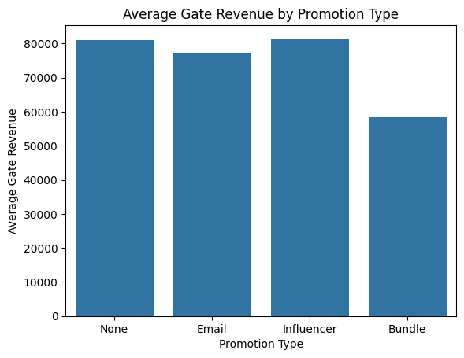

L. Lobster Land management wants to better understand how visitor counts vary acrossthe days of the week. Generate a barplot that shows average total visitors by day of Week.

1. First, create a version of your barplot with the y-axis starting at 0.
2. Next, create a second version of the exact same barplot, but this time set the y-axis to begin just below the lowest average value and end just above the highest average value (so the differences are visually emphasized).

```
Promo_Bar_Plot = sns.barplot(x ='Day_of_Week', y = 'Total_Visitors', errorbar = None, data = lobster_25, estimator = np.mean, color = 'red'),
plt.title('Average Total Visitors by Day of the week'),
plt.xlabel('Day of the week '),
plt.ylabel('Average Total Visitors');
```

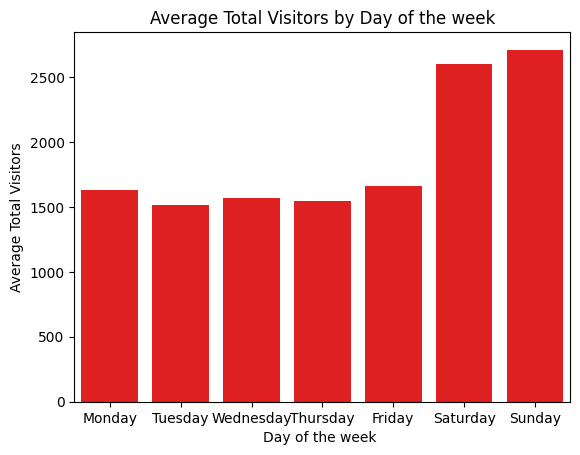

```
avg_visitors = lobster_25.groupby('Day_of_Week')['Total_Visitors'].mean()
ymin = avg_visitors.min() - 50
ymax = avg_visitors.max() + 50
```

```
Promo_Bar_Plot_Updated = sns.barplot(x ='Day_of_Week', y = 'Total_Visitors', errorbar = None, data = lobster_25, estimator = np.mean, color = 'green'),
plt.title('Average Total Visitors by Day of the week (Emphasized)'),
plt.xlabel('Day of the week '),
plt.ylabel('Average Total Visitors'),
plt.ylim(ymin, ymax);
```

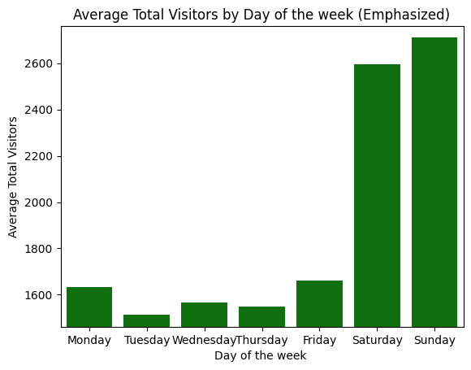

In a few sentences, compare the two plots. How does changing the axis range affect how someone might interpret the magnitude of the differences across days? Why is this important for responsible data communication?

- The first plot show us typically what we might expect regarding total visitors thoughout the week. With average total visitors on Monday - Friday being quite similar and then we observe a major spike in visitors on Saturday & Sunday.
- The changing of the y-axis completely distorts the visualization and how the reader may interpret the data. Looking at the second graph, upon first glance it looks as if the park gets barely any visitors midweek compared to the weekend.

M.

Generate a histogram of per capita spend across all visitors in the 2025 season. Be sure to give your plot a clear, descriptive title.

In a couple of sentences, describe your plot. What does this tell you about the distribution of spending per visitor?

- The plot tells us that the majority of visitors to the park spend on average between 65 - 90 dollars.
- There are some visitors however who spend less than 65 and some outliers on the other end of the scale who spend in excess of 105 dollars per visit.
- One positive to note is that every vistor to the park is spending at least 50 dollars.

```
sns.histplot(x = 'Per_Capita_Spend', data = lobster_25, bins = 15, color = 'blue'),
plt.title('Distribution of Per Capita Spend'),
plt.xlabel('Per Capita Spend'),
plt.ylabel('Count');
```

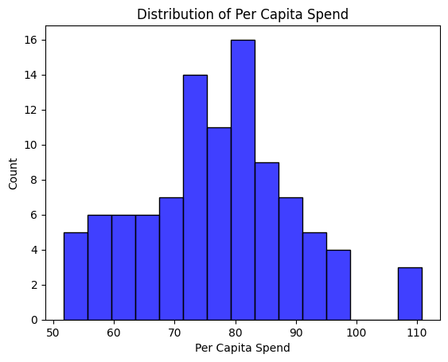

Now, make a second histogram with a different number of bins (either higher or lower than the first one). How does the second histogram differ from the first?

Be specific – what is a takeaway or conclusion that someone might draw from one of these histograms, but not the other?

- Adding 50 bins as apposed to 15 bins gives us a more in-depth view of average per capita spend per visitor.
- The positives of this views sheds some light on vistors exact spending habits. It can give us an idea into how many outliers lie in the extreme soending range of 105 + dollars.
- On the flip side, when categorizing visitors spending habits and analyzing the distribution, it's not necessary to go into this level of detail. A more digestable view might be to place visitors in bins of 60-70 dollars, 70-80 dollars etc.

```
sns.histplot(x = 'Per_Capita_Spend', data = lobster_25, bins = 50, color = 'blue'),
plt.title('Distribution of Per Capita Spend'),
plt.xlabel('Per Capita Spend'),
plt.ylabel('Count');
```

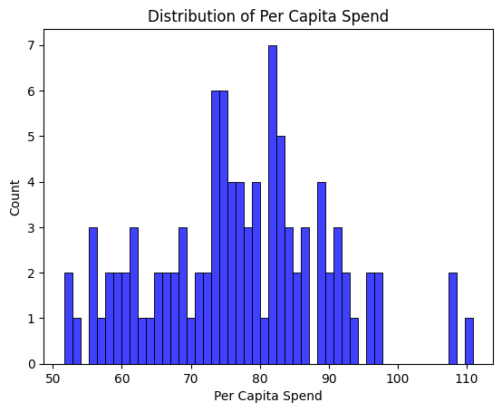

N.

One member of the Lobster Land Board of Directors thinks that people tend to buy more merch on hot days. Let’s see whether the data supports this theory! Generate a scatterplot with the day’s high temperature on the x-axis, and with total merch revenue on the y-axis. Be sure to give your plot a clear, descriptive title.

What does the scatterplot show? If there is a relationship between these variables, what might explain it? If there is not a relationship between these variables, why do you think this is the case?

- The scatterplot shows us that there is no relationship between the two variables. This is unsurprising as I would not expect the weather to be a deciding factor when buying merchandise.
- I would expect to see a strong positive relationship if we looked at the sale of ice cream on hot days.

```
sns.scatterplot(x = 'High_Temperature', y = 'Revenue_Merch', data = lobster_25, color = 'red'),
plt.title('Relationship between High Temperature and Total Merch Revenue'),
plt.xlabel('High Temperature'),
plt.ylabel('Total Merch Revenue');
```

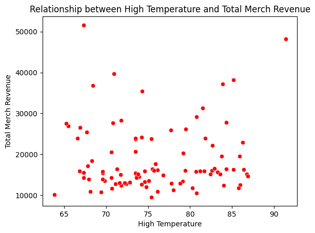

O.

Create a boxplot that shows day of week on one axis and passholder percentage on the other. Be sure to give your plot a clear, descriptive title.

In a few sentences, what does the boxplot reveal? Are some days more “passholder heavy” than others? Why might this be the case?

```
sns.boxplot(x = 'Day_of_Week', y = 'Passholder_Percentage', data = lobster_25, color = 'green'),
plt.title('Passholder Percentage by Day of the Week'),
plt.xlabel('Day of the Week'),
plt.ylabel('Passholder Percentage');
```

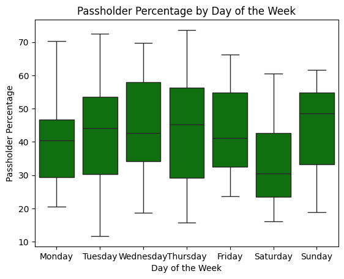

P.

Aggregate the data by month (May, June, July, August, September). Then, create a bar plot that shows average daily total visitors by month. Be sure to give your plot a clear, descriptive title.

What does the plot show? What will you tell management about it?

- At first, the plot makes it look like September had way more daily visitors than any other month. But that’s a bit misleading, since the park was only open for one day in September—Labor Day (September 1st). Because it’s a big holiday in the U.S., attendance was naturally much higher than usual, which throws off the average for the whole month.
- A similar approach can be taken with the data for May, as the park was only open for the last week in May.
- The plot shows June to have the highest average total daily visitors for the month when compared to July & August. June also had the highest daily average temperature for the summer which is interesting to note that naturally the better weather brings out more visitors. For management the drop off in daily visitors in July is slightly concerning and something that needs to be addressed potentially through more promotions and special events.

```
lobster_25['Month'] = lobster_25['Date'].dt.month
avg_visitors_month = lobster_25.groupby('Month')['Total_Visitors'].mean()
avg_visitors_month
```

| Month | Total_Visitors |
| --- | --- |
| 5 | 1751.333333 |
| 6 | 2023.900000 |
| 7 | 1763.548387 |
| 8 | 1888.709677 |
| 9 | 2404.000000 |

**dtype:** float64

```
lobster_25['Month'] = lobster_25['Date'].dt.month_name()
month_order = ['May', 'June', 'July', 'August', 'September']

sns.barplot(x = 'Month', y = 'Total_Visitors', data = lobster_25, estimator = np.mean, errorbar = None, color = 'blue', order = month_order),
plt.title('Average Daily Total Visitors by Month'),
plt.xlabel('Month'),
plt.ylabel('Average Daily Total Visitors');
```

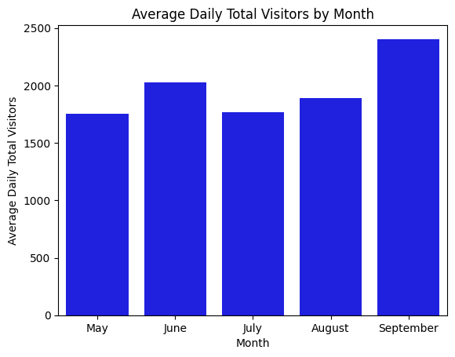

```
sns.barplot(x = 'Month', y = 'High_Temperature', data = lobster_25, estimator = np.mean, errorbar = None, color = 'blue', order = month_order),
plt.title('Average Daily High Temperature by Month'),
plt.xlabel('Month'),
plt.ylabel('Average Daily High Temperature');
```

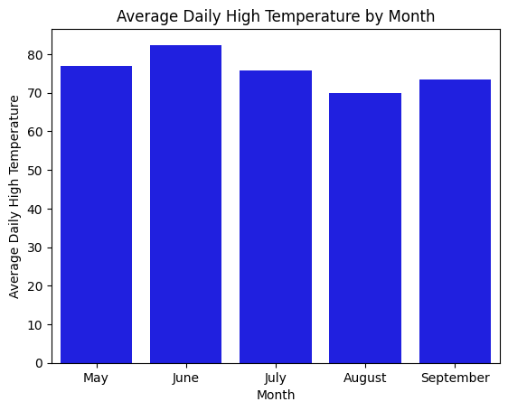

Q.

Generate a barplot that shows special events on one axis and average international visitors on the other. Do not include error bars. Order your bars from tallest to shortest. Be sure to give your plot a clear, descriptive title.

What does your plot show, and why might it look this way? Why can we not conclude causality from this relationship?

- The plot shows the Taylor Swift Lookalike to be the most popular special event among international visitors, followed by MusicFest, Beatles Tribute, Vintage Days & Night Glow.
- We cannot conclude causality from this relationship as there may be more variables influencing this data such as holidays, weekends or even weather. There may be some element of luck or coincidence influencing these variables also as although Taylor Swift is popular, it is unlikely that international visitors are going to fly in especially for the lookalike contest!

```
order = (lobster_25.groupby("Special_Events")["International_Visitors"].mean().sort_values(ascending=False).index)

sns.barplot(x = 'International_Visitors', y = 'Special_Events', data = lobster_25, estimator = np.mean, errorbar = None, color = 'green', order = order),
plt.title('Average International Visitors by Special Event'),
plt.xlabel('International Visitors'),
plt.ylabel('Special Events');
```

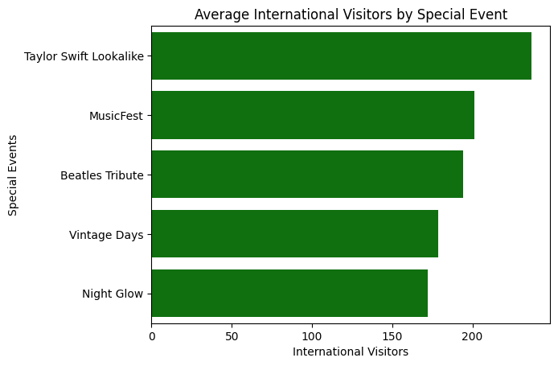

```
sns.countplot(x = 'Special_Events', data = lobster_25, order = order),
plt.title('Count of Special Events'),
plt.xlabel('Special Events'),
plt.ylabel('Count'),
plt.xticks(rotation = 45);
```

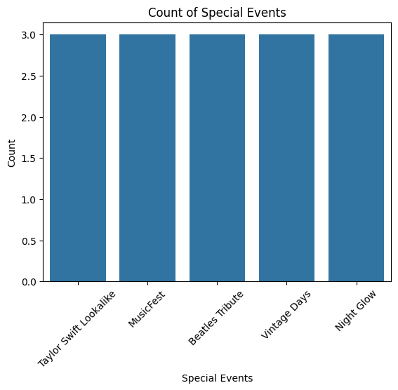

R.

Create a faceted bar plot of food & beverage revenue, with facets for weather type, and bars representing day of the week. Do not include error bars. Be sure to give your plot a clear, descriptive title.

What looks interesting here? Are there certain weather/day combinations that stand out? What’s one important limitation of this visualization?

- It's unfair to try and create a relationship between people's spending habits and the weather as this is an uncontrollable variable. For example, of course revenue for food and beverage is going to be higher on cloudy days when compared against days where there are thunderstorms or showers due to the surplus of people attending the park.
- A more accurate comparison may be between weather types and gate revenue.
- The sample size is also low to make a fair assumption on revenue and weather type. For example we have no data for revenue on Monday's when the weather type was 'showers'. Similarily, on the weekends we have no date for revenue when the weather type was 'thunderstorms'. We don't know was it a case of there was simply no thunderstorms any weekend or did the park close on weekends when thunderstorms were forecasted.

```
sns.barplot(x = 'Day_of_Week', y = 'FoodBev_Rev', data = lobster_25,
            estimator = np.mean, errorbar = None, color = 'red', hue = 'Weather_Type', palette = 'Set2'),
plt.title('Average Food & Beverage Revenue by Day of the Week and Weather Type'),
plt.xlabel('Day of the Week'),
plt.ylabel('Average Food & Beverage Revenue'),
plt.legend(title = 'Weather Type'),
plt.xticks(rotation = 45);
```

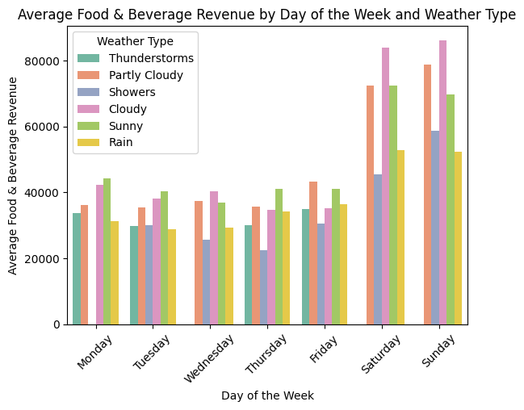

S.

Lobster Land wishes to dig just a bit deeper into its Gold Zone revenue trends across the entire 2025 season. Using Python, create a lineplot that shows season_week_rel on the x-axis, and aggregate (total) Gold Zone spending for that week on the y-axis.

What general trend does this lineplot show, if any? If you were explaining it to an outside audience, what would you point out about the graph?

- The gold zone revenue is erratic with no real trend forming until weeks 10 - 14 where it seems to yo-yo up and down between 200k - 450k.
- One thing to note is that every date a different attraction is emphasized by the park. So on the weeks where gold zone revenue is high such as week 4 & 7, this would suggest that the gold zone was emphasized on multiple days those weeks, and vice versa for weeks where gold zone revenue takes a nosedive.

```
gold_zone_weekly_spending = lobster_25[lobster_25['Attraction_Tier'] == 1].groupby('season_week_rel'),
 ['Total_Revenue'].sum().reset_index(name='Total_Revenue')
```

```
sns.lineplot(x = 'season_week_rel', y = 'Total_Revenue', data = gold_zone_weekly_spending, marker = 'o', color = 'red'),
plt.title('Total Gold Zone Revenue by Season Week'),
plt.xlabel('Season Week'),
plt.ylabel(' Gold Zone Revenue'),
plt.grid = (True);
```

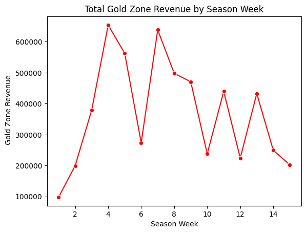

```
gold_zone_weekly_spending
```

|  | season_week_rel | Total_Revenue |
| --- | --- | --- |
| 0 | 1 | 98030.86 |
| 1 | 2 | 199540.42 |
| 2 | 3 | 378786.54 |
| 3 | 4 | 653742.17 |
| 4 | 5 | 562755.43 |
| 5 | 6 | 273480.99 |
| 6 | 7 | 638188.34 |
| 7 | 8 | 497631.46 |
| 8 | 9 | 470718.31 |
| 9 | 10 | 237839.49 |
| 10 | 11 | 439665.69 |
| 11 | 12 | 223944.43 |
| 12 | 13 | 432538.81 |
| 13 | 14 | 249278.08 |
| 14 | 15 | 202565.15 |

**Part III: Wildcard: Metrics and “Quantified Self”** A. For three days, you will gather observational data, acting as both the researcher AND as the subject.

a. Choose any ONE aspect of your daily life that you can quantify. This could be a health metric, a financial metric, an entertainment metric, a metric about a hobby, or just ANYTHING else that you can measure/quantify.

b. For each of the three days, keep track of this metric. Report your findings – what were your numbers?

c. Write ONE thoughtful paragraph about your experience. In your paragraph, you might answer questions such as: What did you learn by tracking this? Did it change your behavior in any way? Did anyone else around you react to what you were doing? Would you consider running the “experiment” for a longer period of time?

- Health Metric I chose - **Casual Reading**
- Tuesday 16th September - 20 pages
- Wednesday 17th September - 28 pages
- Thursday 18th September - 31 pages

I wanted to make an effort and track this metric as I am making a conscious effort myself to read more on a daily basis. I am currently reading a book on Ireland's political & social landscapes since the War of Independence as this is something I'm embarressed to admit I am relatively uneducated on! This is and has been an attempt to wean myself off the dependency of social media as a passtime. Although this is something I've been implementing since towards the end of the summer, I definetely found keeping track of this metric beneficial as it gave me a target to aim for or 'beat' each day. I've learned that the time of the day when I most crave social media is right before bed and when I'm travelling or waiting on publice transport so this is something I need to work on moving foward if I am to kick this bad habit! I will absolutely continue to track this metric moving forward to try and raise my reading up to 40+ pages per day.